# Statistical Principles & Experimental Design Seminar 3 on Expected Values & Statistical Inference

matthias.kuhn@tu-dresden.de

November 20, 2023 <sub>[95982bc]</sub>

**(solutions interspersed)**

## Exponential distribution

Suppose, we have a random variable (RV) $X$ that is **exponentially distributed** with parameter λ > 0 which we note symbolically as $X ∼ \mathop{\mathrm{Exp}}(λ)$. The exponential distribution has a probability density function given by
$$f(x) = \frac{1}{λ} \exp(-\frac{x}{λ}) \quad \text{ for non-negative } x
\text{ and 0 otherwise}$$
This distribution is sometimes used as a probabilistic *model for operating time* of a device when we do *not* expect an ageing effect, i.e., no accelerated failure with increasing time.

1. Visualize the density of the distribution for several possible values of λ. Use `geom_function`. You do not need to provide a dataframe to the initial call to `ggplot()`. It suffices to provide the limits for the x-axis via `xlim`, e.g. start with `ggplot() + xlim(.05, 5) + geom_function(...)`.
2. What is the expected value $\mathop{\mathrm{E}}[X]$ of $X$? What is its variance $\mathop{\mathrm{Var}}[X]$?
3. Consider two *independent* random variables $X ∼ \mathop{\mathrm{Exp}}(λ_1)$ and $Y ∼ \mathop{\mathrm{Exp}}(λ_2)$. How does the distribution of the random variable $Z := \max(X,Y)$ look like? What is the expected value of $Z$?<sub>*(difficult)*</sub> It is best to describe the distribution of $Z$ via its cumulative distribution function (CDF) $F_Z$. For the expectation of $Z$, $F_Z$ is directly helpful as we can integrate over the survival function $1-F_Z$:
   $$\mathop{\mathrm{E}}[Z] = ∫_0^∞ (1-F_Z(t)) dt$$
   This holds for any non-negative random variable $Z$ and is a consequence of *Tonelli’s theorem*.

**Solution**

1. We show the densities of three exponential distributions using `geom_function`. We do not need to specify data but it suffices to set the range on the x-axis via `xlim`.

The simple straight-forward solution calls `geom_function` thrice. We have no legend, though.

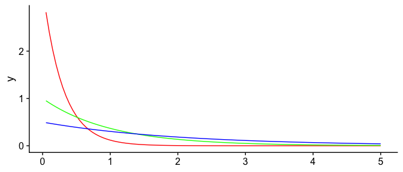

```r
library("ggplot2")
expDens <- function(x, lambda=1) 1/lambda * exp(-x/lambda)

ggplot() + xlim(0.05, 5) +
  # geom_function thrice, for different values of lambda, use manual colour coding
  geom_function(fun = expDens, args = list(lambda=.3), col = "red") +
  geom_function(fun = expDens, args = list(lambda=1), col = "green") +
  geom_function(fun = expDens, args = list(lambda=2), col = "blue")
```

We can also use `purrr::map` to repeatedly call `geom_function` with different values of scale-parameter λ. The advantage is that we get a legend when we map the value of lambda to the function colour.

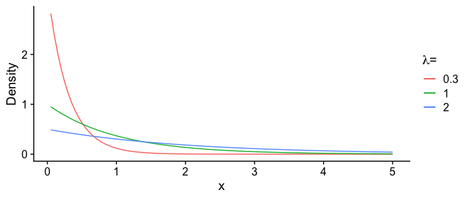

```r
ggplot() + xlim(0.05, 5) +
  # run geom_function for different values of lambda, use colour coding
  purrr::map(.x = c(.3, 1, 2),
             .f = ~ geom_function(mapping = aes(colour = as.character(.)),
                                  fun = expDens, args = list(lambda=.))) +
  labs(x = 'x', y = 'Density',
       # Legend title via colour =
       # math & greek letters, see help via ?plotmath
       colour = expression(lambda * '='))
```

Note: R provides a built-in density function for the exponential distribution, namely `dexp` with a rate parameter. However, `dexp`’s rate parameter corresponds to the inverse λ<sup>-1</sup> in our given formula.

2. When a density is defined the **expected value** of $X$ is calculated as the integral $\mathop{\mathrm{E}}[X] = \int_{-∞}^∞ x · f(x) dx$. In the case of the exponential density we can solve this integral via *integration by parts*. as the integrand is a product of two functions $u(x) = x$ and $v'(x) = \frac{1}{λ} · \exp(-\frac{x}{λ})$. The anti-derivative $v(x) = -\exp(-\frac{x}{λ}) + C$ (for some constant $C$) has a simpler form and facilitates the integration in the end:

$$\begin{align}
\mathop{\mathrm{E}}[X] &= \int_0^∞ x · \frac{1}{λ}
\exp(-\frac{x}{λ}) dx\\
&= -x \exp(-\frac{x}{λ}) \,\Big|_0^∞ - \int_0^∞ -
\exp(-\frac{x}{λ}) dx \\
&= -0 + \int_0^∞ \exp(-\frac{x}{λ}) dx \qquad \text{ (using
rule of de l'Hospital) }\\
&= -λ · \exp(-\frac{x}{λ}) \,\Big|_0^∞ = λ
\end{align}$$

Hence, if $X ∼ \mathop{\mathrm{Exp}}(λ)$ models the operating time for a device then its expected operating time is λ.

The **variance** of our random variable $X$ is defined as $\mathop{\mathrm{Var}}(X) := \mathop{\mathrm{E}}[(X-\mathop{\mathrm{E}}[X])^2] = \mathop{\mathrm{E}}[X^2] - \mathop{\mathrm{E}}[X]^2$. What remains unknown is $\mathop{\mathrm{E}}[X^2]$ which is the following integral and which is solved by applying *integration by parts*, again:
$$\begin{align}
\mathop{\mathrm{E}}[X^2] &= \int_0^∞ x^2 · \frac{1}{λ}
\exp(-\frac{x}{λ}) dx \\
&= -x^2 \exp(-\frac{x}{λ}) \,\Big|_0^∞ - \int_0^∞ - 2x ·
\exp(-\frac{x}{λ}) dx\\
&= 2 \int_0^∞ x · \exp(-\frac{x}{λ}) dx\\
&= 2λ · \int_0^∞ x · \frac{1}{λ} \exp(-\frac{x}{λ}) dx\\
&= 2λ · \mathop{\mathrm{E}}[X]\\
&= 2λ^2
\end{align}$$
Hence, $\mathop{\mathrm{Var}}(X) = 2λ^2 - λ^2 = λ^2$. The higher the expected value λ of $X$ the higher also its variance. $X$’s coefficient of variation $\operatorname{CV}(X) := \frac{\sqrt{\mathop{\mathrm{Var}}(X)}}{\mathop{\mathrm{E}}[X]}$, a standardized measure of dispersion, is constant, though: $\operatorname{CV}(X) = 1$.

3. $Z$ is defined as the maximum of two independent exponentially distributed random variables. The distribution of $Z$ is described by its **cumulative distribution function (CDF)** $F_Z: ℝ → [0; 1]$ with $F_Z(z) := P(Z≤z)$. It is:
   $$\begin{align}
   F_Z(z) &:= P(Z≤z) = P(\max(X,Y) ≤ z) = P(X≤z, Y≤z)\\
   &\stackrel{\text{indep.}}{=} P(X≤z) · P(Y≤z) = F_X(z) · F_Y(z)
   \end{align}$$
   The cumulative distribution function of an exponentially distribution random variable $X$ with parameter λ is:
   $$F_X (x) := \int_{-∞}^x f_X(t) dt = \int_{0}^x \frac{1}{λ}
   \exp(-\frac{t}{λ}) dt
   = -\exp(-\frac{t}{λ}) \,\Big|_{t=0}^{t=x} = 1 - \exp(-\frac{x}{λ})$$

Hence, we get Z’s CDF as:
$$\begin{align}
F_Z(z) &= (1 - \exp(-\frac{z}{λ_1})) · (1 - \exp(-\frac{z}{λ_2}))\\
&= 1 - \exp(-\frac{z}{λ_1}) - \exp(-\frac{z}{λ_2}) +
\exp(-\frac{z}{λ_1} - \frac{z}{λ_2})\\
&= 1 - \exp(-\frac{z}{λ_1}) - \exp(-\frac{z}{λ_2}) +
\exp(-\frac{z}{\frac{λ_1 λ_2}{λ_1+λ_2}})
\end{align}$$

Now we can proceed either by taking the derivative of $F_Z$ to get the density of $Z$ and from there use again integration to get the expectation of $Z$ — or — we can use the following result («Tonelli’s theorem») for *random variables with non-negative support*
$$\mathop{\mathrm{E}}[Z] = \int_0^∞ (1 - F_Z(z)) dz$$
In our case this gives:
$$\begin{align}
\mathop{\mathrm{E}}[Z] &= \int_0^∞ \exp(-\frac{z}{λ_1}) +
\exp(-\frac{z}{λ_2}) - \exp(-\frac{z}{\frac{λ_1 λ_2}{λ_1+λ_2}}) dz\\
&= -λ_1 \exp(-\frac{z}{λ_1}) - λ_2 \exp(-\frac{z}{λ_2}) + \frac{λ_1
λ_2}{λ_1+λ_2} \exp(-\frac{z}{\frac{λ_1 λ_2}{λ_1+λ_2}})
\,\Big|_{z=0}^{z=∞}\\
&= λ_1 + λ_2 - \frac{λ_1 λ_2}{λ_1+λ_2}
\end{align}$$
This is twice the arithmetic mean minus half the harmonic mean of the two parameters.

## Expected value and squared deviation

1. You draw a random point $P$ from the square from last week’s exercise. What is the expected area $E[A_Δ]$ of the triangle between the three points P and south-west corner (-1, -1) and south-east corner (+1, -1)?
2. Consider the squared deviation of a real random variable X from some constant $b∈ℝ$:
   $$Y_b := (X - b)^2 ≥ 0$$
   $Y_b$ is also a random variable as it depends on $X$. For which value of $b$ does $Y_b$ on average (i.e., in expectation) take a minimal value?

**Solution**

1. The area $A_Δ$ of a triangle with base side of length 2 and height $h$ is calculated as $½ · 2 · h = h$. The height of the triangle solely depends on the $Y$-coordinate of the sampled point $P$, i.e. the $X$-coordinate of $P$ does *not* effect the area of the triangle. The height of the triangle in terms of the $Y$-coordinate is $h = 1+y$ and the area of the triangle as function of coordinates $(X,Y)$ is simply:
   $$g(X,Y) = 1+Y$$
   Hence, for the expected area of the triangle we integrate:
   $$\begin{align}
   E[A_Δ] &= \int_{-1}^1 \int_{-1}^1 g(X,Y) f_{X,Y} \;dx \,dy \\
   &= \int_{-1}^1 \int_{-1}^1 (1+y) · ¼ \;dx \,dy \\
   &= ¼ \int_{-1}^1 (1+y) · \int_{-1}^1 1 \;dx \, dy \\
   &= ½ \int_{-1}^1 (1+y)\; dy = ½ · \, \big(\frac{y^2}{2} + y
   \big)\,\Big|_{y=-1}^{y=+1}\\
   &= ½ · \{ ½ + 1 - ½ + 1 \} = 1
   \end{align}$$
   Because the $X$-coordinate does not matter the solution can be calculated directly using only the one-dimensional uniform distribution of $Y$ on the interval [-1, 1], i.e. starting directly with $E[A_Δ] = \int_{-1}^1 (1+y) ½ \; dy$.
2. We consider the expected value of the RV $Y_b$ as a function of $b$ and we use algebraic transformations to show that there exists a general lower bound.

We suspect that the expected value $E[X] = μ$ of the RV $X$ plays a special role and we write:
$$\begin{align}
E[Y_b] &= E[(X-b)^2] \\
&= E[(X-μ + μ - b)^2]\\
&= E[(X-μ)^2 + 2 (X-μ)(μ-b) + (μ-b)^2]\\
&= \mathop{\mathrm{Var}}(X) + 2 (μ-b) E[X-μ] + (μ-b)^2\\
&= \mathop{\mathrm{Var}}(X) + 2 (μ-b) 0 + (μ-b)^2\\
&= \mathop{\mathrm{Var}}(X) + (μ-b)^2\\
&≥ \mathop{\mathrm{Var}}(X)
\end{align}$$
And this minimum is reached if and only if $b=μ$.

Hence, the **expected value** of a RV $X$ **minimizes** the **expected squared difference** to $X$.

## Maximum Likelihood for Normal Data

In the lecture you have learned that within parametric inference about a parameterized distribution for a given vector of observations $\mathbf{x}$ the **likelihood function** assigns to each possible parameter θ its likelihood. The **maximum likelihood estimate (MLE)** is that parameter value $\hat θ$ that maximizes the likelihood function.

In the lecture you have seen the first part of the derivation of MLE for normal data. Starting point was an i.i.d. (=independent and identically distributed) random sample from a normal distribution, i.e., realizations $\mathbf{x} = x_1, \ldots, x_n$ of random variables $X_1, \ldots, X_n \stackrel{\text{iid}}{\sim} N(μ, σ^2)$, with both $μ ∈ ℝ$ and $σ^2 ∈ ℝ^+$ unknown.

The likelihood and respectively the log-likelihood functions in this situation are
$$\begin{align*}
L(μ, σ^2 ; \mathbf{x})& =\frac{1}{\sqrt{2\pi σ^2}^n} \cdot \exp( -
\sum_{i=1}^n \frac{(x_i - μ)^2}{2 σ^2} )\\
l(μ, σ^2 ; \mathbf{x})& = -\frac{n}{2}\ln(2\pi) -\frac{n}{2}\ln(σ^2)
- \frac{1}{2 σ^2} \cdot \sum_{i=1}^n (x_i - μ)^2
\end{align*}$$
By equating the first partial derivatives of the log-likelihood function to zero (the «likelihood equations») you come to the *candidate values for the MLE* for expected value and variance of the normal distribution:
$$\hat μ = \bar x \qquad \text{ and } \qquad \hat σ^2 = \frac{1}{n}
\sum_{i=1}^n (x_i - \bar x)^2$$

### Task 1: Local maximum

Verify that vector of these two values is really a **local maximum** of the likelihood function (and not a local minimum or an inflection point). You may look into the second-order derivative. As it is a two-variate function this involves the 2x2-matrix of second-order partial derivatives (the **Hesse-matrix** $H$). A candidate value is a local maximum if you show that $H$ is *negative definite* there, — this means 1. at least one second-order partial derivative $\frac{\partial}{\partialμ^2}l(μ, σ^2)$ or $\frac{\partial}{\partial(σ^2)^2}l(μ, σ^2)$ is negative *and* 2. the determinant of the Hesse-matrix is positive at that value.

**Solution**

We have the following Hessian-matrix:
$$H=
\begin{bmatrix}
-\frac{n}{σ^2}& -\frac{1}{(σ^2)^2}\sum_i^n(x_i - μ)\\
-\frac{1}{(σ^2)^2}\sum_i^n(x_i - μ)& \frac{n}{2 (σ^2)^2} -
\frac{\sum_i^n(x_i - μ)^2}{(σ^2)^3}
\end{bmatrix}$$
The second order partial derivative $\frac{\partial}{\partialμ^2}l(μ, σ^2)$ is negative for all values $(μ, σ^2)$.

For any value of μ and σ<sup>2</sup>, and using $SS_x := ∑(x_i - µ)^2$ it is:
$$\det H = \frac{n}{σ^6} · \big[ \frac{n-1}{σ^2} (μ - \bar x)^2 +
\frac{SS_x}{σ^2} - \frac{n}{2} \big]$$
Note that the determinant of $H$ might turn negative for very large values of σ<sup>2</sup> but the determinant of $H$ *at the candidate value* $(\hat μ = \bar x, \hat σ^2)$ simplifies to $\frac{1}{\hat σ^6} \frac{n^2}{2} > 0$ because it is $∑(x_i - \bar x) = 0$ and $SS_x = ∑(x_i - \bar x)^2 = n · \hat σ^2$. Hence, $H$ is negative definite at that point and we have shown that there is a local maximum.

### Task 2: Global maximum<sub>*(extra)*</sub>

Show that this local maximum is actually a **global maximum**, i.e., that the function takes no higher values in the boundaries of the parameter domain than the local maximum. As this is not so easy for a two-variate function: Do you see an argument that you can focus on the variance parameter $σ^2$ when checking for a global maximum? Then, it is rather straightforward to verify that the function does not attain a global maximum at the boundary of the domain, $σ^2 \searrow 0$ or $σ^2 \rightarrow ∞$.

**Solution**

In the log-likelihood function the parameter $μ$ appears only in the term $-\sum_{i=1}^n(x_i - μ)^2$. It is $\sum_{i=1}^n(x_i -a)^2 = \sum_{i=1}^n(x_i-\bar x)^2 + n \cdot (\bar x - a)^2 \ge \sum_{i=1}^n(x_i-\bar x)^2$. The equality is reached if and only if $a=\bar x$. This means that regarding the mean $μ$ our candidate $\hat μ = \bar x$ minimizes $\sum_{i=1}^n(x_i - μ)^2$. Because of the minus sign before the sum term in the log-likelihood $\hat μ = \bar x$ for $μ$ gives hence the maximal value globally for the log-likelihood function no matter what we choose for $σ^2$.

Therefore, we only need to show that we have a global maximum at the candidate value with respect to the variance parameter $σ^2$.

Now, for smooth univariate functions with only a single local extremum that is a local maximum there can not be a global maximum at the boundaries. If there were a global maximum at the boundaries there would necessarily be a local minimum as well in between the local maximum and the global maximum at the boundary.

As we have seen only a single candidate point for a local extremum with respect to $σ^2$, the local maximum at $(\hat μ, \hat σ^2)$ must be the global maximum as well.

### Task 3: Visualization

Finally, let’s visualize the log-likelihood function with a concrete sample:

- Draw a normal sample $\mathbf{x}$ with $μ=3$ and $σ^2 = 4$ of size $n=13$
- Plot the log-likelihood function for this sample as a function of $σ^2$ with $μ = \bar x$ fixed. Using `geom_function` from `ggplot2` you can plot the graph of a function. You do not need to provide a dataframe, the domain of the function to be plotted can be specified via `ggplot`’s `xlim()`.

**Solution**

```r
# draw a sample
set.seed(1234) # for reproducibility
x <- rnorm(13, mean=3, sd=2)
xb <- mean(x)

# log-likelihood function for parameters expectation and variance, given a sample of data
logLikFun <- function(m, s2, smpl) {
  n <- length(smpl)
  -n/2 * log(2 * pi) - n/2 * log(s2) - sum((smpl-m)^2)/(2*s2)
}

logLikFun(m=xb, s2=6, smpl = x) #to test our log-likelihood
```

```
## [1] -26.717
```

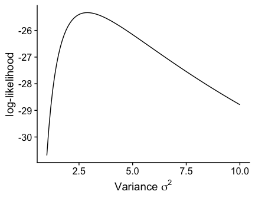

```r
# plot log-likelihood
ggplot() + xlim(1, 10) +
  geom_function(fun = logLikFun, args = list(m = mean(x), smpl = x)) +
  labs(x=expression('Variance '*sigma^2), y='log-likelihood')
```

The log-likelihood is only a function of the unknown parameters to be estimated. Therefore, it is annoying that for `logLikFun` we need to carry around the sample data for each call to the log-likelihood. In R, it is possible to avoid this by making use of a so-called **function factory**. A function factory is a function that returns itself a function, in our case we provide the sample data and get back the log-likelihood function that already incorporates the sample data. https://adv-r.hadley.nz/function-factories.html has more explanation on function factories in R.

```r
# log-likelihood "factory"
# produces the log-likelihood for a given sample
logLikFactory <- function(smpl) {
  n <- length(smpl)
  function(m, s2) -n/2 * log(2 * pi) - n/2 * log(s2) - sum((smpl-m)^2)/(2*s2)
}

logLikFun2 <- logLikFactory(smpl = x) # produce log-likelihood for sample x
logLikFun2(m=xb, s2=6) # no need to provide the data here
```

```
## [1] -26.717
```

## Confidence Intervals

In frequentist statistics, a confidence interval (CI) for the mean of a normally distributed measurement variable with unknown variance σ<sup>2</sup> can be calculated based on an *i.i.d.* random sample of size $n$ as follows:

$$\begin{equation}
\bar{X} ± t_{n-1; 1-α/2}\frac{\hat{S}}{\sqrt{n}}
\end{equation}$$

where

- $\bar{X}$ denotes the sample mean,
- $t_{n-1;1-α/2}$ the $1-\tfrac{α}{2}$-quantile of the t-distribution with $n-1$ degrees of freedom,
- $\hat{S}$ the estimated standard deviation
- the term $\tfrac{\hat{S}}{\sqrt{n}}$ is the estimate of the standard error of the mean (SEM)

Hence, the width of confidence intervals for the mean depends on the three parameters α, estimated standard deviation $\hat S$ and sample size $n$. Now try to figure out how the width of the confidence intervals changes by varying one of the three parameters and keeping the others fixed.

1. Implement a function that – given the sample data and α – returns the estimated mean and its (1-α)-confidence interval and the width of the confidence interval.
2. Draw samples of size $n=\{2, 3, 5, 10, 25, 100, 500, 1000\}$ from a normal distribution with fixed $μ = 0$ and variance $σ^2 = 4$. Visualize how the width of the CI with fixed $α = 0.05$ depends on the sample size $n$.
3. Draw samples of size $n=25$ from a normal distribution with fixed $μ = 0$ and varying variances $σ^2 = \{0.5, 1, 4, 9, 25, 50\}$. Visualize how the width of the CI with fixed $\alpha = 0.05$ depends on the used variability in the data.
4. Draw a sample of size $n=25$ from a normal distribution with $μ = 0$ and variance $σ^2 = 4$. Visualize how the width of the CI depends on the varying levels of $α = \{0.001, 0.01, 0.05, 0.1, 0.15, 0.2, 0.25\}$.

**Solution**

We write a function called `ci.mean` that calculates the mean, the requested confidence interval and its width.

```r
ci.mean <- function(data, alpha) {
  # empirical mean
  mymean <- mean(data)

  # estimated standard error of the mean
  mySEM <- sd(data) / sqrt(length(data))

  # confidence interval
  ci <- mymean + c(-1,1) * qt(1-alpha/2, df=length(data)-1) * mySEM

  # width of confidence interval
  width <- diff(ci) ## or, directly: ci[2] - ci[1]

  # return multiple parameters as a list
  list(mean=mymean, ci=ci, ci.width=width)
}
```

Now, we use our function `ci.mean` to evaluate the effect of the different parameters. On the y-axis we show the width of the confidence interval on **log-scale**.

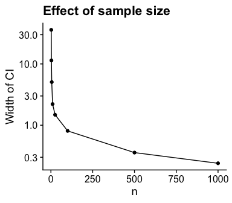

```r
set.seed(98765) #reproducible "randomness"
resN <- tibble(n = c(2, 3,5,10, 25, 100, 500, 1000))
# add width for each sample size n
resN$width <- purrr::map_dbl(
  .x = resN$n,
  .f = \(n) ci.mean(data = rnorm(n=n, sd=2), alpha = .05)$ci.width
)

ggplot(resN, mapping = aes(x=n, y=width)) +
  geom_line() + geom_point() +
  scale_y_log10(name = "Width of CI") +
  labs(title = "Effect of sample size", x = "n")
```

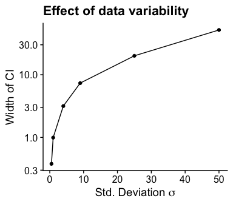

```r
resSD <- tibble(sigma = c(.5, 1, 4, 9, 25, 50))
resSD$width <- purrr::map_dbl(
  .x = resSD$sigma,
  .f = \(sgm) ci.mean(data = rnorm(n=25, sd=sgm), alpha = .05)$ci.width
)
```

The bigger the variability in the data the wider gets the confidence interval on average.

To test the effect of the error level α on the width of the confidence interval, we draw one random sample of size `n=25` and repeatedly calculate the width of the confidence interval for varying error levels:

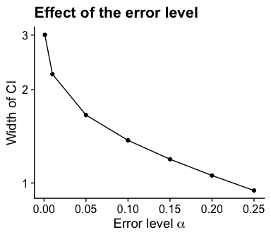

```r
mySmpl <- rnorm(n=25, sd=2)

resErr <- tibble(alpha = c(0.001, 0.01, 0.05, 0.1, 0.15, 0.2, 0.25))
resErr$width <- purrr::map_dbl(
  .x = resErr$alpha,
  .f = \(alpha) ci.mean(data = mySmpl, alpha = alpha)$ci.width
)
```

The smaller α (i.e., the higher the confidence level 1-α) the wider gets the confidence interval.

A note on R-programming: there is also an elegant variant how to run a simulation over different settings that are stored in a dataframe (or tibble). Namely using `rowwise()` in combination with `mutate` (both from `dplyr`) you can enforce that each calculation is done for each row separately. This way, you do not need to specify a name for the results dataframe but you could feed forward the dataframe into the plotting routine. For instance, the code for the effect of varying sample size `n` could be re-written as:

```r
tibble(n = c(2, 3, 5, 10, 25, 100, 500, 1000)) |>
  # do mutate-operations separately for each row!
  dplyr::rowwise() |>
  dplyr::mutate(width = ci.mean(data = rnorm(n=n, sd=2), alpha = .05)$ci.width)
```